# literature

## 1.4 Environmental Variables

### 1.4.1 Sea Surface Temperature

Figure 1.9 shows the monthly value of sst between 2015 and 2018. The surface temperature show a seasonal pattern of low and high values. The temperature is relatively low between May and October and gradually start warming from November to February and reach maximum in March.

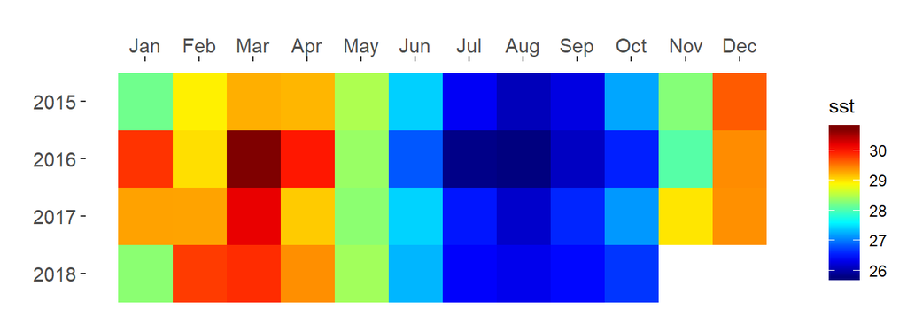

Figure 1.9: Monthly sea surface temperature within the areas of Somanga and Songosongo between 2015 and 2018

The surface temperature of surface water around Mafia Island vary with season, on average, the surface water is warmer during the northeast (Figure 1.10a) than southeast (Figure 1.10b). However, the temperature differrence is not homogenous, with the areas surrounding the Bwejuu Island and western side of Mafia Island experience low temperature difference between the two seasons (Figure 1.10)

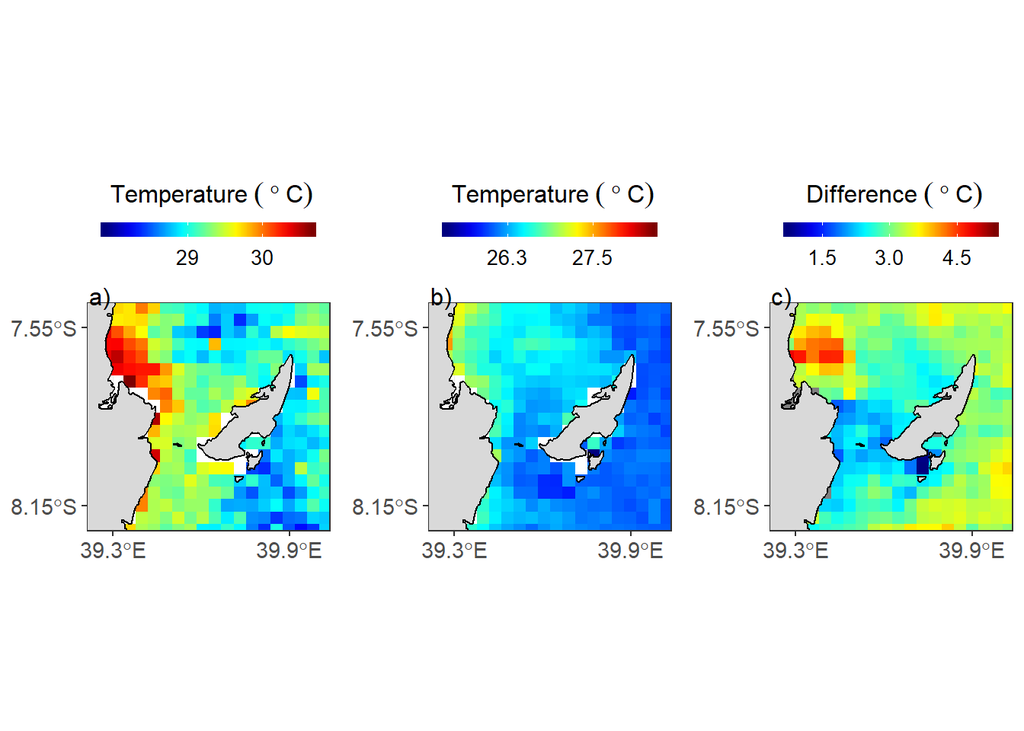

Figure 1.10: Sea surface temperature around Mafia Island for a) March b) August and and c) is the difference in temperature between March and August. The griided data were processed from MODIS

The surface temperature of surface water around Kilwa vary with season, the surface water is warmer during the northeast (Figure 1.11a) than southeast (Figure 1.11b). However, the temperature differrence is not homogenous, with the coastal water experience a less temperature difference between the two seasons (Figure 1.11)

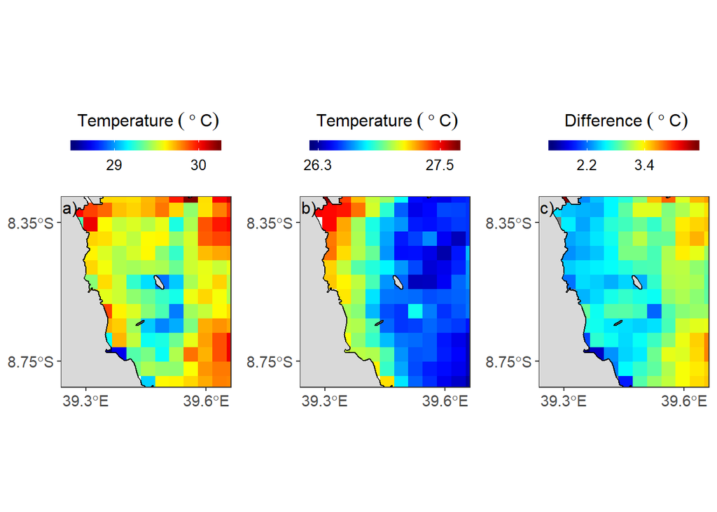

Figure 1.11: Sea surface temperature around Kilwa for a) March b) August and c) is the difference in temperature between March and August. The griided data were processed from MODIS